# QMM_HW6

Celijah

10/31/2019

```r
library(lpSolveAPI)
library(ucminf)
library(Benchmarking)
```

1. Formulation of DEA analysis

```r
input <- matrix(c(150,400,320,520,350,320, 0.2, 0.7, 1.2, 2.0, 1.2, 0.7),ncol = 2)
output <- matrix(c(14000,14000,42000,28000,19000, 14000, 3500,21000,10500,42000,25000,15000), ncol= 2)

colnames(input) <- c("Staff Hours Per Day", "Supplies Per Day")
colnames(output) <- c("Reimbursed Patient-Days", "Privately Paid Patient-Days")
```

##FDH

```r
fdh <- dea(input, output, RTS = "fdh")
fdh
```

```
## [1] 1 1 1 1 1 1
```

```r
peers(fdh)
```

```
##      peer1
## [1,]     1
## [2,]     2
## [3,]     3
## [4,]     4
## [5,]     5
## [6,]     6
```

```r
lambda(fdh)
```

```
##      L1 L2 L3 L4 L5 L6
## [1,]  1  0  0  0  0  0
## [2,]  0  1  0  0  0  0
## [3,]  0  0  1  0  0  0
## [4,]  0  0  0  1  0  0
## [5,]  0  0  0  0  1  0
## [6,]  0  0  0  0  0  1
```

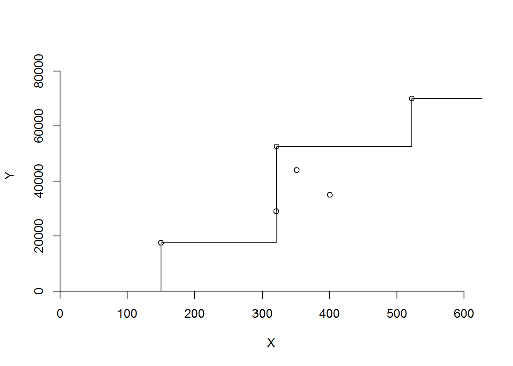

```r
dea.plot(input, output, RTS = "fdh")
```

##CRS

```r
crs <- dea(input, output, RTS = "crs")
crs
```

```
## [1] 1.0000 1.0000 1.0000 1.0000 0.9775 0.8675
```

```r
peers(crs)
```

```
##      peer1 peer2 peer3
## [1,]     1    NA    NA
## [2,]     2    NA    NA
## [3,]     3    NA    NA
## [4,]     4    NA    NA
## [5,]     1     2     4
## [6,]     1     2     4
```

```r
lambda(crs)
```

```
##             L1         L2 L3        L4
## [1,] 1.0000000 0.00000000  0 0.0000000
## [2,] 0.0000000 1.00000000  0 0.0000000
## [3,] 0.0000000 0.00000000  1 0.0000000
## [4,] 0.0000000 0.00000000  0 1.0000000
## [5,] 0.2000000 0.08048142  0 0.5383307
## [6,] 0.3428571 0.39499264  0 0.1310751
```

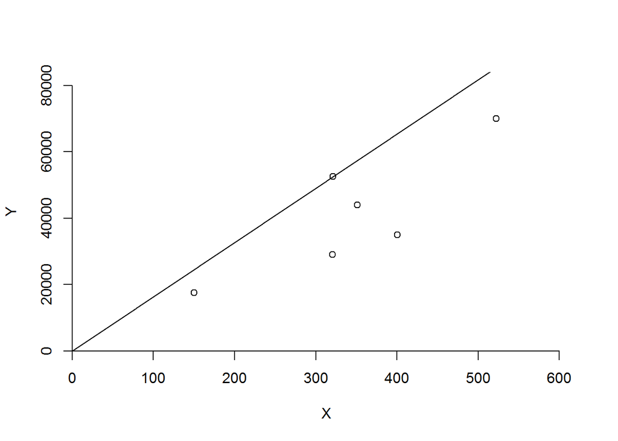

```r
dea.plot(input, output, RTS = "crs")
```

##VRS

```r
vrs <- dea(input, output, RTS = "vrs")
vrs
```

```
## [1] 1.0000 1.0000 1.0000 1.0000 1.0000 0.8963
```

```r
peers(vrs)
```

```
##      peer1 peer2 peer3
## [1,]     1    NA    NA
## [2,]     2    NA    NA
## [3,]     3    NA    NA
## [4,]     4    NA    NA
## [5,]     5    NA    NA
## [6,]     1     2     5
```

```r
lambda(vrs)
```

```
##             L1        L2 L3 L4        L5
## [1,] 1.0000000 0.0000000  0  0 0.0000000
## [2,] 0.0000000 1.0000000  0  0 0.0000000
## [3,] 0.0000000 0.0000000  1  0 0.0000000
## [4,] 0.0000000 0.0000000  0  1 0.0000000
## [5,] 0.0000000 0.0000000  0  0 1.0000000
## [6,] 0.4014399 0.3422606  0  0 0.2562995
```

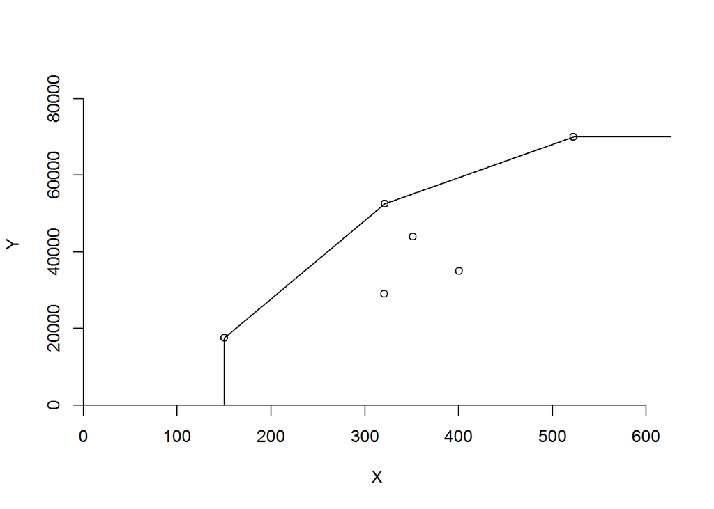

```r
dea.plot(input, output, RTS = "vrs")
```

##IRS

```r
irs <- dea(input, output, RTS = "irs")
irs
```

```
## [1] 1.0000 1.0000 1.0000 1.0000 1.0000 0.8963
```

```r
peers(irs)
```

```
##      peer1 peer2 peer3
## [1,]     1    NA    NA
## [2,]     2    NA    NA
## [3,]     3    NA    NA
## [4,]     4    NA    NA
## [5,]     5    NA    NA
## [6,]     1     2     5
```

```r
lambda(irs)
```

```
##             L1        L2 L3 L4        L5
## [1,] 1.0000000 0.0000000  0  0 0.0000000
## [2,] 0.0000000 1.0000000  0  0 0.0000000
## [3,] 0.0000000 0.0000000  1  0 0.0000000
## [4,] 0.0000000 0.0000000  0  1 0.0000000
## [5,] 0.0000000 0.0000000  0  0 1.0000000
## [6,] 0.4014399 0.3422606  0  0 0.2562995
```

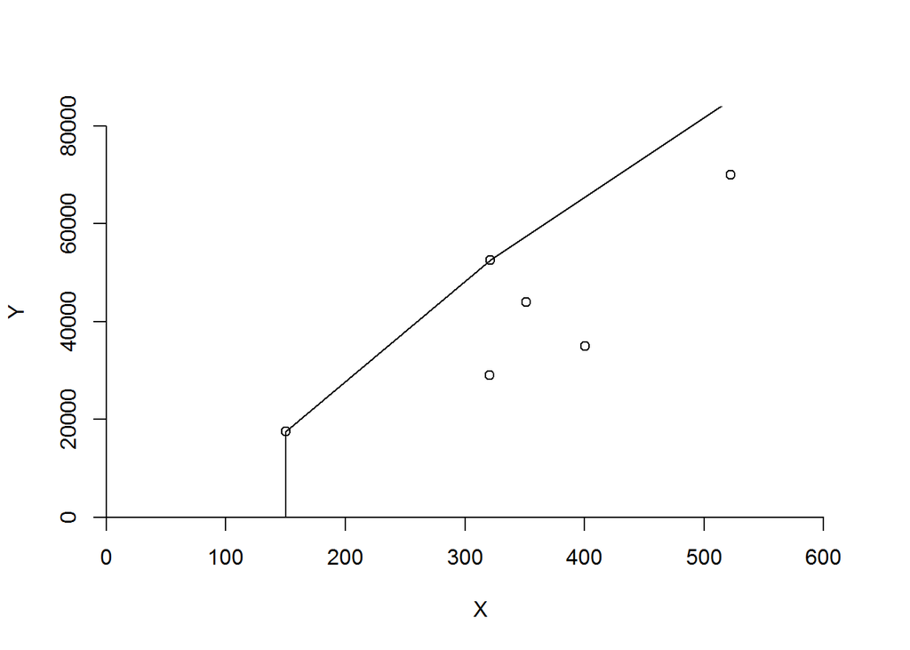

```r
dea.plot(input, output, RTS = "irs")
```

##DRS

```r
drs <- dea(input, output, RTS = "drs")
irs
```

[output not shown]

```r
peers(drs)
```

```
##      peer1 peer2 peer3
## [1,]     1    NA    NA
## [2,]     2    NA    NA
## [3,]     3    NA    NA
## [4,]     4    NA    NA
## [5,]     1     2     4
## [6,]     1     2     4
```

```r
lambda(drs)
```

```
##             L1         L2 L3        L4
## [1,] 1.0000000 0.00000000  0 0.0000000
## [2,] 0.0000000 1.00000000  0 0.0000000
## [3,] 0.0000000 0.00000000  1 0.0000000
## [4,] 0.0000000 0.00000000  0 1.0000000
## [5,] 0.2000000 0.08048142  0 0.5383307
## [6,] 0.3428571 0.39499264  0 0.1310751
```

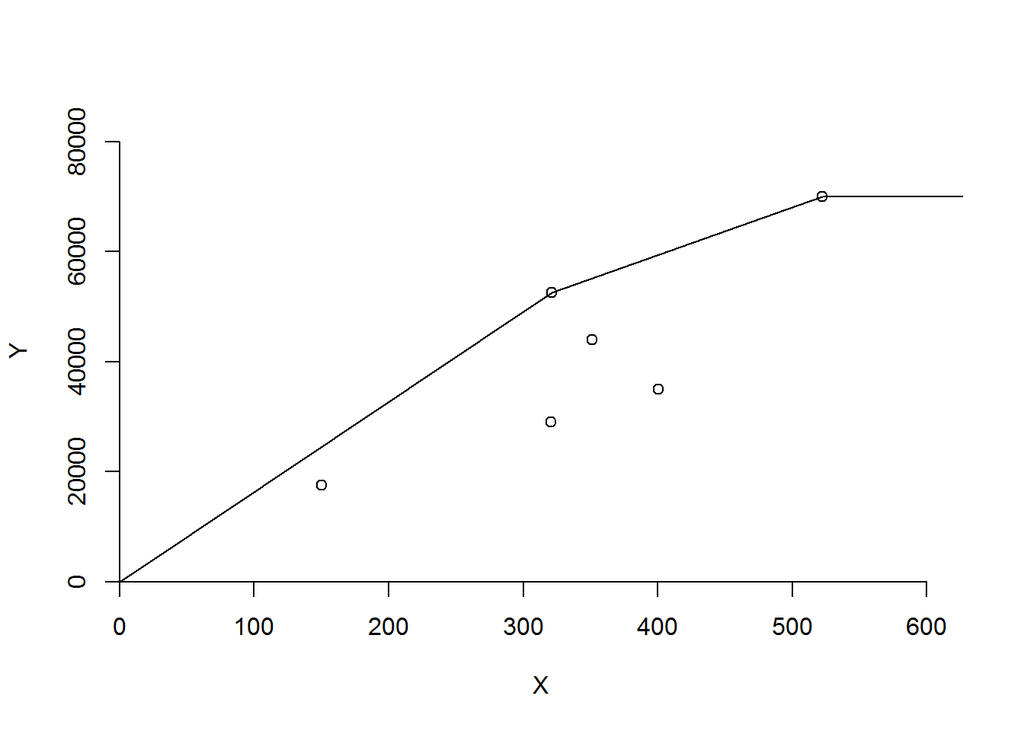

```r
dea.plot(input, output, RTS = "drs")
```

##FRH or FDH

```r
fdh <- dea(input, output, RTS = "fdh")
fdh
```

```
## [1] 1 1 1 1 1 1
```

```r
peers(fdh)
```

```
##      peer1
## [1,]     1
## [2,]     2
## [3,]     3
## [4,]     4
## [5,]     5
## [6,]     6
```

```r
lambda(fdh)
```

```
##      L1 L2 L3 L4 L5 L6
## [1,]  1  0  0  0  0  0
## [2,]  0  1  0  0  0  0
## [3,]  0  0  1  0  0  0
## [4,]  0  0  0  1  0  0
## [5,]  0  0  0  0  1  0
## [6,]  0  0  0  0  0  1
```

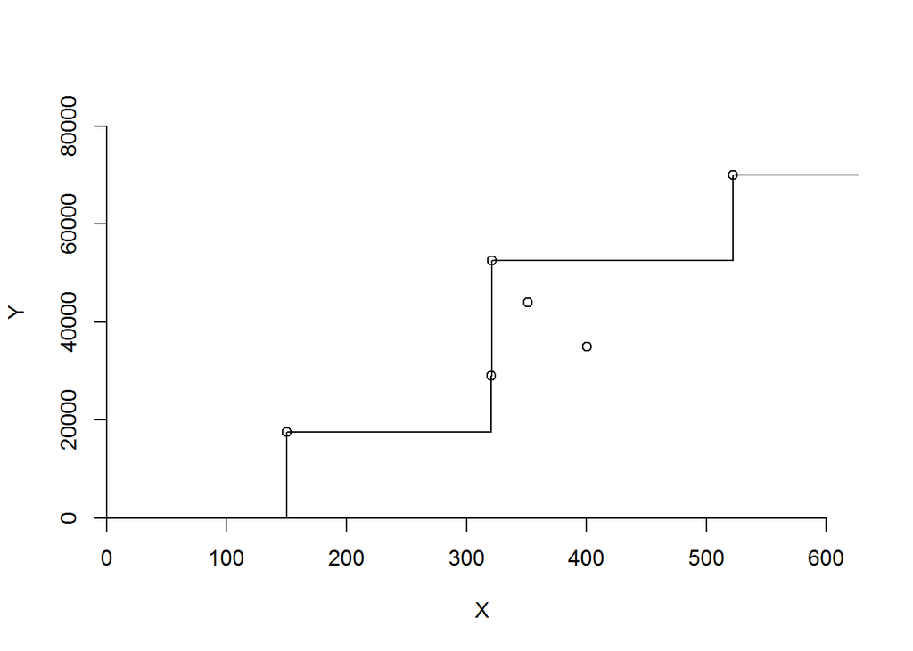

```r
dea.plot(input, output, RTS = "fdh")
```

##Problem 2: Goal Programming

1. Define y1+ and y1-, respectively, as the amount over (if any) and the amount under (if any) the employment level goal. Define y2+ and y2- in the same way for the goal regarding earnings next year. Define x1, x2, and x3 as the production rates of Products 1, 2, and 3, respectively. With these definitions, use the goal programming technique to express y1+, y1- , y2+ and y2- algebraically in terms of x1, x2, and x3. Also express P in terms of x1, x2, and x3.
2. Express managements objective function in terms of x1, x2, x3, y1+, y1- , y2+ and y2-.
3. Formulate and solve the linear programming model. What are your findings?

```r
library("lpSolveAPI")
```

```
min: 5 y1n + 2000 y2p + 4 y2n + 3000 y3p;


12 x1 + 9 x2 + 15 x3 - y1p + y1n = 125;
5 x1 + 3 x2 + 4 x3 - y2p + y2n = 40;
5 x1 + 7 x2 + 8 x3 - y3p +  y3n = 55;

x1 >= 0;
x2 >= 0;
x3 >= 0;

y1p >= 0;
y2p >= 0;
y3p >= 0;

y1n >= 0;
y2n >= 0;
y3n >= 0;
```

```r
gp <- read.lp("gp_celijah.lp")

gp
```

```
## Model name:
##   a linear program with 9 decision variables and 3 constraints
```

```r
solve(gp)
```

```
## [1] 0
```

```r
get.objective(gp)
```

```
## [1] 43.75
```

```r
vars <- get.variables(gp)

names(vars) <- c("y1n", "y2p", "y2n", "y3p", "x1" ,"x2", "x3", "y1p", "y3n")

vars
```

```
##  y1n  y2p  y2n  y3p   x1   x2   x3  y1p  y3n
## 8.75 0.00 0.00 0.00 5.00 0.00 3.75 0.00 0.00
```